# **Flow-Based Network Intrusion Detection (Binary Classification) — Machine Learning Study**

#### Author: Luis Rito Filipe

#### June, 2023

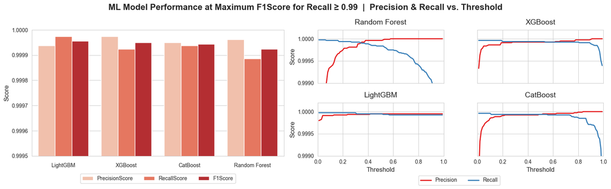

# Summary

This study evaluates multiple machine learning models for network intrusion detection, formulated as a binary classification problem, with the objective of maximizing attack detection while minimizing false positives.

Among the evaluated models, LightGBM was selected as the final model, as it consistently achieved high performance across all evaluation metrics and satisfied the defined constraint (Recall ≥ 0.99). While differences between the top-performing models are minimal, LightGBM provides a favorable balance between recall and precision under threshold tuning, aligning with the objective of maximizing attack detection while maintaining acceptable false positive rates.

The results further indicate that attack detection is largely driven by a limited subset of flow-based features. Despite variations in feature importance across models, all approaches achieve near-perfect classification performance, suggesting that the dataset exhibits strong intrinsic separability in the selected feature space.

# About The Study

The objective of this study is to compare machine learning algorithms when applied to data analysis to detect network attacks. To achieve this, I will leverage widely used Python libraries specialized in data analysis and machine learning, including tools for data manipulation, visualization, and predictive modeling. The study will progress from exploratory data analysis to more advanced techniques, such as feature engineering and fraud detection modeling, to provide meaningful insights into the characteristics of network attacks detection.

# About The Dataset

The following study uses a dataset of network intrusion publicly available from Kaggle (see link below). The dataset was produced by Canadian Institute for Cybersecurity.

Dataset link: https://www.kaggle.com/datasets/chethuhn/network-intrusion-dataset

# Data Wrangling

Two datasets with exact the same 79 features, one with DDoS attacks and other with PortScan attacks, were used. After loading and merging the datasets, data was prepared.

```
<class 'pandas.core.frame.DataFrame'>
RangeIndex: 512212 entries, 0 to 512211
Columns: 79 entries,  Destination Port to  Label
dtypes: float64(24), int64(54), object(1)
memory usage: 308.7+ MB
```

|  | Destination Port | Flow Duration | Total Fwd Packets | Total Backward Packets | Total Length of Fwd Packets | Total Length of Bwd Packets | Fwd Packet Length Max | Fwd Packet Length Min | Fwd Packet Length Mean | Fwd Packet Length Std | Bwd Packet Length Max | Bwd Packet Length Min | Bwd Packet Length Mean | Bwd Packet Length Std | Flow Bytes/s | Flow Packets/s | Flow IAT Mean | Flow IAT Std | Flow IAT Max | Flow IAT Min | Fwd IAT Total | Fwd IAT Mean | Fwd IAT Std | Fwd IAT Max | Fwd IAT Min | Bwd IAT Total | Bwd IAT Mean | Bwd IAT Std | Bwd IAT Max | … |
| --- | --- | --- | --- | --- | --- | --- | --- | --- | --- | --- | --- | --- | --- | --- | --- | --- | --- | --- | --- | --- | --- | --- | --- | --- | --- | --- | --- | --- | --- | --- |
| count | 512212.000000 | 5.122120e+05 | 512212.000000 | 512212.000000 | 512212.000000 | 5.122120e+05 | 512212.000000 | 512212.000000 | 512212.000000 | 512212.000000 | 512212.000000 | 512212.000000 | 512212.000000 | 512212.000000 | 5.121930e+05 | 5.122120e+05 | 5.122120e+05 | 5.122120e+05 | 5.122120e+05 | 5.122120e+05 | 5.122120e+05 | 5.122120e+05 | 5.122120e+05 | 5.122120e+05 | 5.122120e+05 | 5.122120e+05 | 5.122120e+05 | 5.122120e+05 | 5.122120e+05 | … |
| mean | 8412.769090 | 1.016663e+07 | 4.091019 | 3.984264 | 544.584561 | 4.141029e+03 | 282.666408 | 18.078026 | 86.143519 | 108.468259 | 1309.471908 | 22.736429 | 435.251879 | 573.344087 | inf | inf | 8.887531e+05 | 2.246625e+06 | 6.963890e+06 | 1.883560e+04 | 9.724758e+06 | 1.555440e+06 | 2.574144e+06 | 6.718783e+06 | 3.421505e+05 | 5.671966e+06 | 8.635275e+05 | 9.312839e+05 | 2.890904e+06 | … |
| std | 17447.963843 | 2.712714e+07 | 17.841275 | 25.620921 | 2592.815800 | 4.619398e+04 | 1281.867186 | 110.274825 | 347.365649 | 544.842538 | 2800.858963 | 52.869257 | 860.129260 | 1298.281072 | NaN | NaN | 2.473728e+06 | 6.080575e+06 | 1.983521e+07 | 5.790381e+05 | 2.704408e+07 | 6.023558e+06 | 7.771771e+06 | 2.023747e+07 | 5.002368e+06 | 2.159339e+07 | 5.574226e+06 | 4.089487e+06 | 1.265023e+07 | … |
| min | 0.000000 | -1.300000e+01 | 1.000000 | 0.000000 | 0.000000 | 0.000000e+00 | 0.000000 | 0.000000 | 0.000000 | 0.000000 | 0.000000 | 0.000000 | 0.000000 | 0.000000 | -1.930000e+08 | -2.000000e+06 | -1.300000e+01 | 0.000000e+00 | -1.300000e+01 | -1.300000e+01 | 0.000000e+00 | 0.000000e+00 | 0.000000e+00 | 0.000000e+00 | -1.200000e+01 | 0.000000e+00 | 0.000000e+00 | 0.000000e+00 | 0.000000e+00 | … |
| 25% | 80.000000 | 5.500000e+01 | 1.000000 | 1.000000 | 2.000000 | 6.000000e+00 | 2.000000 | 0.000000 | 2.000000 | 0.000000 | 6.000000 | 0.000000 | 6.000000 | 0.000000 | 1.568228e+02 | 3.160119e+00 | 5.333333e+01 | 0.000000e+00 | 5.500000e+01 | 3.000000e+00 | 0.000000e+00 | 0.000000e+00 | 0.000000e+00 | 0.000000e+00 | 0.000000e+00 | 0.000000e+00 | 0.000000e+00 | 0.000000e+00 | 0.000000e+00 | … |
| 50% | 146.000000 | 3.027600e+04 | 2.000000 | 1.000000 | 26.000000 | 6.000000e+00 | 6.000000 | 2.000000 | 6.000000 | 0.000000 | 6.000000 | 6.000000 | 6.000000 | 0.000000 | 2.634817e+04 | 1.656658e+02 | 7.943167e+03 | 1.154744e+02 | 2.456900e+04 | 2.200000e+01 | 3.000000e+00 | 3.000000e+00 | 0.000000e+00 | 3.000000e+00 | 1.000000e+00 | 0.000000e+00 | 0.000000e+00 | 0.000000e+00 | 0.000000e+00 | … |
| 75% | 5544.000000 | 2.033681e+06 | 4.000000 | 4.000000 | 62.000000 | 3.500000e+02 | 36.000000 | 6.000000 | 33.000000 | 6.094494 | 191.250000 | 6.000000 | 159.000000 | 9.899495 | 1.666667e+05 | 3.636364e+04 | 3.703694e+05 | 8.667981e+05 | 1.989960e+06 | 5.600000e+01 | 2.799100e+05 | 6.571646e+04 | 3.254759e+04 | 1.933665e+05 | 4.600000e+01 | 1.108765e+05 | 2.356893e+04 | 2.751521e+04 | 8.520375e+04 | … |
| max | 65532.000000 | 1.199999e+08 | 3119.000000 | 3635.000000 | 232349.000000 | 7.150819e+06 | 13929.000000 | 1472.000000 | 3867.000000 | 6692.644993 | 11680.000000 | 1460.000000 | 5800.500000 | 8194.660487 | inf | inf | 1.070000e+08 | 8.480000e+07 | 1.200000e+08 | 1.070000e+08 | 1.200000e+08 | 1.200000e+08 | 8.120000e+07 | 1.200000e+08 | 1.200000e+08 | 1.200000e+08 | 1.200000e+08 | 8.130000e+07 | 1.200000e+08 | … |

In this study only a subset from the 79 initial features was used (Flow Bytes/s, Flow Packets/s, Fwd Packets/s, Bwd Packets/s, Subflow Fwd Packets, Subflow Fwd Bytes, Packet Length Std, Packet Length Variance, Flow Duration, Init_Win_bytes_forward, Init_Win_bytes_backward, Down/Up Ratio, Label).

There are 10 features with only one unique value, which imply they have zero variance and cannot help distinguishing Label 0 vs Label 1. Mathematically, for models like logistic regression, the coefficient becomes meaningless and it may even cause numerical instability in some cases. If any of these were included in the subset used, it would also be removed.

Label feature contains three unique values. "BENIGN" will be replaced by 0 (normal), and "DDoS" and "PortScan" by 1 (attack). Label feature was renamed to Class. A space before or after each feature name was removed. A few rows with infinite values were removed. Rows with values of -1 in features "Init_Win_bytes_forward" and "Init_Win_bytes_backward" were removed as this is an indication that the information was not available or not applicable for a particular flow.

# Exploratory Data Analysis

Feature correlation analysis helped identify strongly correlated feature pairs, allowing for the removal of redundant variables and improving model robustness. Below, the summary statistics of the dataset reduced and prepared for the machine learning algorithms. The dataset shows moderate class imbalance (69.3% attack traffic).

|  | Flow Bytes/s | Flow Packets/s | Subflow Fwd Packets | Subflow Fwd Bytes | Packet Length Std | Flow Duration | Init_Win_bytes_forward | Init_Win_bytes_backward | Down/Up Ratio | Class |
| --- | --- | --- | --- | --- | --- | --- | --- | --- | --- | --- |
| count | 3.466440e+05 | 3.466440e+05 | 346644.000000 | 346644.000000 | 346644.000000 | 3.466440e+05 | 346644.000000 | 346644.000000 | 346644.000000 | 346644.000000 |
| mean | 1.648106e+05 | 3.464620e+04 | 4.674046 | 774.300178 | 746.880217 | 1.357641e+07 | 11308.381547 | 1337.718048 | 1.110866 | 0.693037 |
| std | 1.571201e+06 | 1.193475e+05 | 21.462025 | 3124.136830 | 1134.641265 | 3.164487e+07 | 12910.440954 | 6922.772750 | 1.129737 | 0.461235 |
| min | -1.930000e+08 | -2.000000e+06 | 1.000000 | 0.000000 | 0.000000 | -1.300000e+01 | 0.000000 | 0.000000 | 0.000000 | 0.000000 |
| 25% | 5.948222e+02 | 4.353305e+00 | 1.000000 | 0.000000 | 2.309401 | 4.800000e+01 | 1024.000000 | 0.000000 | 1.000000 | 0.000000 |
| 50% | 8.695652e+04 | 1.526718e+04 | 1.000000 | 6.000000 | 3.464102 | 1.520000e+02 | 8192.000000 | 0.000000 | 1.000000 | 1.000000 |
| 75% | 1.600000e+05 | 4.255319e+04 | 3.000000 | 50.000000 | 1633.102694 | 1.856222e+06 | 29200.000000 | 229.000000 | 1.000000 | 1.000000 |
| max | 6.170000e+08 | 3.000000e+06 | 3119.000000 | 232349.000000 | 4731.522394 | 1.199999e+08 | 65535.000000 | 65535.000000 | 124.000000 | 1.000000 |

The following chart illustrates the correlation between the target variable Class and the independent features. The results indicate that no feature exhibits a strong correlation, positive or negative.

It is important to note that correlation measures linear relationships only and does not capture potential nonlinear interactions between variables. Therefore, features with low correlation may still contribute to model performance when combined with other variables or when nonlinear effects are considered.

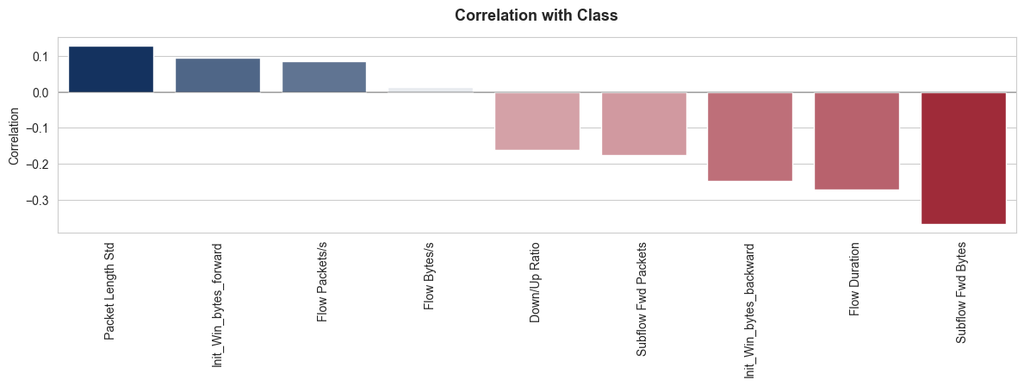

Boxplot analysis highlights that attack traffic (Class 1) generally exhibits fewer outliers across most features, indicating more regular and constrained behavior compared to normal traffic, particularly in features such as “Subflow Fwd Bytes” and “Subflow Fwd Packets”. This supports the idea that normal traffic, associated with browsing, streaming, downloads, and API interactions, is more diverse, whereas attack traffic tends to be automated and repetitive in nature. However, feature "Flow Duration" shows notable outliers for attack traffic, suggesting occasional extreme deviations, possibly corresponding to bursts of activity or sustained attack flows. Overall, attack patterns appear more structured but also revealing sporadic high-intensity events.

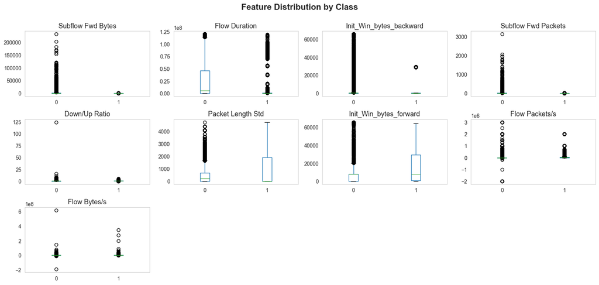

In the next step, the dataset is split into training and testing sets to allow proper training of the classification models and unbiased evaluation of their performance.

```
X_train.shape= (232251, 9) Y_train.shape= (232251,)
X_test.shape= (114393, 9) Y_test.shape= (114393,)
```

## Logistic Regression

Logistic Regression is a supervised machine learning algorithm used for classification tasks, particularly binary classification problems where the target variable takes values such as 0/1, true/false, or yes/no. In this study, it is applied to predict the "Class" variable, which indicates whether network flows are associated with attacks or not. Despite its simplicity, Logistic Regression can perform well in high-dimensional datasets and provide a strong baseline for comparison with more complex models. Given the large number of observations relative to the number of features in this dataset, the model is less likely to overfit, although regularization and class imbalance handling remain important considerations. The coefficients of the Logistic Regression model provide insight into the direction and relative importance of each feature. Positive values indicate an increase in the likelihood of a network flow being classified as attack, while negative values indicate the opposite. The magnitude of the coefficients reflects the strength of the relationship. Below is the implementation of Logistic Regression with hyperparameter tuning, with emphasis on the adjustment of class weights.

|  | Threshold | PrecisionScore | RecallScore | F1Score | TP | TN | FP | FN | MCC |
| --- | --- | --- | --- | --- | --- | --- | --- | --- | --- |
| 50 | 0.50 | 0.935009 | 0.995182 | 0.964157 | 78897 | 29630 | 5484 | 382 | 0.879658 |
| 51 | 0.51 | 0.936061 | 0.995144 | 0.964698 | 78894 | 29725 | 5389 | 385 | 0.881529 |
| 52 | 0.52 | 0.936558 | 0.995093 | 0.964939 | 78890 | 29770 | 5344 | 389 | 0.882358 |
| 53 | 0.53 | 0.936656 | 0.995068 | 0.964979 | 78888 | 29779 | 5335 | 391 | 0.882497 |
| 54 | 0.54 | 0.937046 | 0.995068 | 0.965186 | 78888 | 29814 | 5300 | 391 | 0.883211 |

The following table shows the computed feature coefficients ordered from the highest to the lowest.

|  | 0 | 1 | 2 | 3 | 4 | 5 | 6 | 7 | 8 |
| --- | --- | --- | --- | --- | --- | --- | --- | --- | --- |
| Feature | Packet Length Std | Flow Duration | Init_Win_bytes_forward | Flow Packets/s | Flow Bytes/s | Init_Win_bytes_backward | Down/Up Ratio | Subflow Fwd Bytes | Subflow Fwd Packets |
| Coefficient | 10.632 | 1.421 | 0.995 | 0.073 | -0.303 | -1.012 | -1.733 | -42.989 | -46.788 |

A confusion matrix is shown below for a minimum probability equal to the threshold corresponding to the maximum F1Score for a RecallScore equal or higher than 0.99.

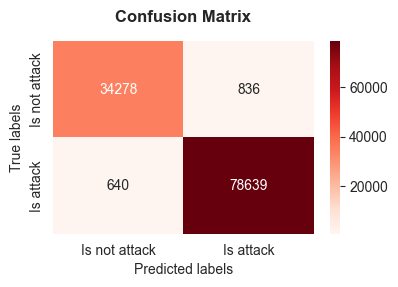

## Random Forest

Random Forest is often expected to outperform Logistic Regression in network intrusion tasks, as it can capture nonlinear patterns, interactions between features, and is generally more robust regarding noise. The Random Forest hyperparameter search was optimized to reduce computational cost/time by limiting tree complexity and reducing cross-validation folds, while preserving model comparability across experiments.

|  | Threshold | PrecisionScore | RecallScore | F1Score | TP | TN | FP | FN | MCC |
| --- | --- | --- | --- | --- | --- | --- | --- | --- | --- |
| 50 | 0.50 | 0.999962 | 0.999836 | 0.999899 | 79266 | 35111 | 3 | 13 | 0.999671 |
| 51 | 0.51 | 0.999962 | 0.999836 | 0.999899 | 79266 | 35111 | 3 | 13 | 0.999671 |
| 52 | 0.52 | 0.999975 | 0.999836 | 0.999905 | 79266 | 35112 | 2 | 13 | 0.999692 |
| 53 | 0.53 | 0.999987 | 0.999811 | 0.999899 | 79264 | 35113 | 1 | 15 | 0.999671 |
| 54 | 0.54 | 0.999987 | 0.999798 | 0.999893 | 79263 | 35113 | 1 | 16 | 0.999651 |

The following table shows the computed feature importance ordered from the highest to the lowest.

|  | 0 | 1 | 2 | 3 | 4 | 5 | 6 | 7 | 8 |
| --- | --- | --- | --- | --- | --- | --- | --- | --- | --- |
| Feature | Subflow Fwd Bytes | Flow Bytes/s | Init_Win_bytes_backward | Packet Length Std | Init_Win_bytes_forward | Flow Packets/s | Flow Duration | Subflow Fwd Packets | Down/Up Ratio |
| Importance | 0.235 | 0.207 | 0.19 | 0.147 | 0.069 | 0.051 | 0.037 | 0.034 | 0.03 |

There is a noticeable difference in the importance attributed to features "Subflow Fwd Bytes" by each algorithm. "Subflow Fwd Bytes" measures how much forward data is transmitted within segments of a flow, providing insight into how traffic volume is distributed rather than just the total amount. A subflow is a segment of a larger flow. Attack flows (Class 1) tend to send less data forward per segment. This feature may reveal important patterns that can be captured by tree models such as Random Forest.

A confusion matrix is shown below for a minimum probability equal to the threshold corresponding to the maximum F1Score for a RecallScore equal or higher than 0.99.

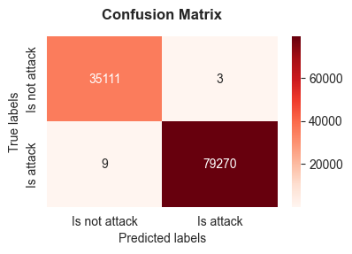

## XGBoost

XGBoost is expected to show similar metrics compared to Random Forest in this task. Reducing the subsample and colsample_bytree (min ≥ 0.7) from default values (1.0) introduces randomness, reduces overfitting, improves generalization, forces feature diversity and reduces dominance of strong features. Shares some similarities with Random Forest. But while the later builds trees during training and outputs the average of the predictions from individual trees, XGBoost builds new trees sequentially and each new tree corrects errors from the previous tree, improving model's predictions.

|  | Threshold | PrecisionScore | RecallScore | F1Score | TP | TN | FP | FN | MCC |
| --- | --- | --- | --- | --- | --- | --- | --- | --- | --- |
| 50 | 0.50 | 0.999924 | 0.999937 | 0.999931 | 79274 | 35108 | 6 | 5 | 0.999774 |
| 51 | 0.51 | 0.999924 | 0.999937 | 0.999931 | 79274 | 35108 | 6 | 5 | 0.999774 |
| 52 | 0.52 | 0.999924 | 0.999937 | 0.999931 | 79274 | 35108 | 6 | 5 | 0.999774 |
| 53 | 0.53 | 0.999924 | 0.999937 | 0.999931 | 79274 | 35108 | 6 | 5 | 0.999774 |
| 54 | 0.54 | 0.999924 | 0.999924 | 0.999924 | 79273 | 35108 | 6 | 6 | 0.999753 |

The following table shows the computed feature importance from the highest to the lowest.

|  | 0 | 1 | 2 | 3 | 4 | 5 | 6 | 7 | 8 |
| --- | --- | --- | --- | --- | --- | --- | --- | --- | --- |
| Feature | Flow Bytes/s | Subflow Fwd Bytes | Packet Length Std | Init_Win_bytes_backward | Subflow Fwd Packets | Init_Win_bytes_forward | Flow Packets/s | Down/Up Ratio | Flow Duration |
| Importance | 1092.0 | 817.0 | 799.0 | 349.0 | 138.0 | 125.0 | 67.0 | 67.0 | 13.0 |

A confusion matrix is shown below for a minimum probability equal to the threshold corresponding to the maximum F1Score for a RecallScore equal or higher than 0.99.

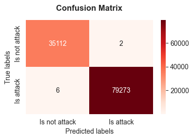

## LightGBM

LightGBM is a high-performance gradient boosting framework built on decision tree algorithms. It is widely used for ranking, classification, and many other machine learning tasks. Works particularly well with large datasets and a large number of independent variables, optimizing heavily for speed and memory efficiency. LightGBM grows trees leaf-wise, evaluates all leaves and expands the single leaf that reduces the loss the most. It uses histogram-based algorithms to group continuous feature values into discrete bins. This drastically reduces memory usage and speeds up training. It can handle categorical features directly without requiring to manually apply encoding first. Because leaf-wise growth is quite aggressive, LightGBM can easily overfit, especially on smaller datasets. To prevent this, careful tuning of hyperparameters like max_depth, num_leaves, and min_data_in_leaf is strictly required.

|  | Threshold | PrecisionScore | RecallScore | F1Score | TP | TN | FP | FN | MCC |
| --- | --- | --- | --- | --- | --- | --- | --- | --- | --- |
| 50 | 0.50 | 0.99995 | 0.999950 | 0.999950 | 79275 | 35110 | 4 | 4 | 0.999836 |
| 51 | 0.51 | 0.99995 | 0.999950 | 0.999950 | 79275 | 35110 | 4 | 4 | 0.999836 |
| 52 | 0.52 | 0.99995 | 0.999937 | 0.999943 | 79274 | 35110 | 4 | 5 | 0.999815 |
| 53 | 0.53 | 0.99995 | 0.999937 | 0.999943 | 79274 | 35110 | 4 | 5 | 0.999815 |
| 54 | 0.54 | 0.99995 | 0.999937 | 0.999943 | 79274 | 35110 | 4 | 5 | 0.999815 |

The following table shows the computed feature importance from the highest to the lowest.

|  | 0 | 1 | 2 | 3 | 4 | 5 | 6 | 7 | 8 |
| --- | --- | --- | --- | --- | --- | --- | --- | --- | --- |
| Feature | Flow Bytes/s | Init_Win_bytes_backward | Subflow Fwd Bytes | Packet Length Std | Init_Win_bytes_forward | Flow Packets/s | Subflow Fwd Packets | Down/Up Ratio | Flow Duration |
| Importance | 698680.0 | 510218.0 | 501723.0 | 182248.0 | 41158.0 | 5448.0 | 4223.0 | 3728.0 | 1305.0 |

A confusion matrix is shown below for a minimum probability equal to the threshold corresponding to the maximum F1Score for a RecallScore equal or higher than 0.99.

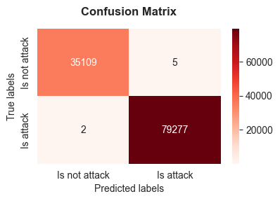

## CatBoost

CatBoost is a high-performance gradient boosting framework built on decision tree algorithms. It is widely used for classification, regression, and ranking tasks, particularly on tabular data. CatBoost introduces ordered boosting, a technique designed to reduce overfitting by preventing information leakage during training. It also uses symmetric trees, where the same splitting condition is applied across each level, improving prediction speed and model stability. One of its main advantages is the ability to handle categorical features directly without requiring extensive preprocessing. CatBoost is generally robust to hyperparameter choices and requires less tuning compared to other gradient boosting frameworks. However, it can be slower to train than LightGBM, especially on very large datasets.

Although CatBoost provides a large number of configurable hyperparameters, it typically requires less manual tuning than frameworks such as LightGBM or XGBoost, due to its robust default settings and built-in mechanisms for handling categorical features and reducing overfitting.

|  | Threshold | PrecisionScore | RecallScore | F1Score | TP | TN | FP | FN | MCC |
| --- | --- | --- | --- | --- | --- | --- | --- | --- | --- |
| 50 | 0.50 | 0.999937 | 0.999937 | 0.999937 | 79274 | 35109 | 5 | 5 | 0.999795 |
| 51 | 0.51 | 0.999937 | 0.999937 | 0.999937 | 79274 | 35109 | 5 | 5 | 0.999795 |
| 52 | 0.52 | 0.999950 | 0.999937 | 0.999943 | 79274 | 35110 | 4 | 5 | 0.999815 |
| 53 | 0.53 | 0.999950 | 0.999937 | 0.999943 | 79274 | 35110 | 4 | 5 | 0.999815 |
| 54 | 0.54 | 0.999950 | 0.999937 | 0.999943 | 79274 | 35110 | 4 | 5 | 0.999815 |

The following table shows the computed feature importance from the highest to the lowest.

|  | 0 | 1 | 2 | 3 | 4 | 5 | 6 | 7 | 8 |
| --- | --- | --- | --- | --- | --- | --- | --- | --- | --- |
| Feature | Subflow Fwd Bytes | Init_Win_bytes_backward | Packet Length Std | Init_Win_bytes_forward | Down/Up Ratio | Flow Bytes/s | Flow Duration | Flow Packets/s | Subflow Fwd Packets |
| Importance | 35.0 | 25.0 | 13.0 | 9.0 | 6.0 | 5.0 | 3.0 | 3.0 | 2.0 |

A confusion matrix is shown below for a minimum probability equal to the threshold corresponding to the maximum F1Score for a RecallScore equal or higher than 0.99.

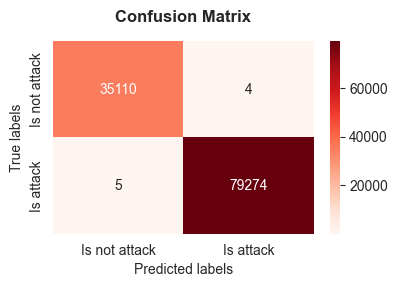

## Model Comparison and Selection

The next step is to define the desired model outcome. If minimizing false positives is the priority in attacks detection, then configurations with higher precision should be preferred. However, this comes at the cost of increased false negatives, meaning that more attacks may go undetected.

|  | Model | Threshold | PrecisionScore | RecallScore | F1Score | TP | TN | FP | FN | MCC | LogLoss | BrierScoreLoss | ROC_AUC | PR_AUC |
| --- | --- | --- | --- | --- | --- | --- | --- | --- | --- | --- | --- | --- | --- | --- |
| 0 | LightGBM | 0.28 | 0.999937 | 0.999975 | 0.999956 | 79277 | 35109 | 5 | 2 | 0.999856 | 0.000623 | 0.000067 | 0.999985 | 0.999995 |
| 1 | XGBoost | 0.79 | 0.999975 | 0.999924 | 0.999950 | 79273 | 35112 | 2 | 6 | 0.999836 | 0.000469 | 0.000074 | 0.999988 | 0.999996 |
| 2 | CatBoost | 0.52 | 0.999950 | 0.999937 | 0.999943 | 79274 | 35110 | 4 | 5 | 0.999815 | 0.000526 | 0.000074 | 0.999989 | 0.999996 |
| 3 | Random Forest | 0.38 | 0.999962 | 0.999886 | 0.999924 | 79270 | 35111 | 3 | 9 | 0.999753 | 0.000984 | 0.000137 | 0.999983 | 0.999994 |
| 4 | Logistic Regression | 0.69 | 0.989481 | 0.991927 | 0.990703 | 78639 | 34278 | 836 | 640 | 0.969635 | 0.170828 | 0.047918 | 0.991434 | 0.994889 |

Based on the model comparison results, LightGBM, XGBoost, CatBoost, and Random Forest exhibit very similar performance, with only marginal differences across evaluation metrics.

All four tree-based models achieve near-perfect recall and precision, indicating that the dataset is highly separable using the selected flow-based features. LightGBM achieves slightly higher recall and F1-score at a tuned decision threshold while maintaining a very low number of false positives, which is desirable in intrusion detection systems where missed attacks are costly.

Although LightGBM shows marginally lower ROC-AUC and PR-AUC values compared to other models, these differences are negligible and do not impact practical performance.

Logistic Regression also performs strongly, achieving high precision and recall, which suggests that the underlying patterns in the data are largely linearly separable. However, ensemble tree-based methods provide slight improvements by capturing non-linear interactions between features.

Overall, the extremely high performance across all models indicates that the dataset exhibits strong intrinsic separability, rather than the superiority of a specific algorithm.

In the context of network intrusion detection, recall is the most critical metric, as failing to detect attacks has severe consequences. Precision remains important to limit false positives and maintain system usability. Given these considerations, and its slightly superior recall performance under threshold tuning, LightGBM is selected as the final model.

It is important to note that the dataset presents moderate class imbalance (aprox. 69% attack traffic), and the near-perfect evaluation metrics suggest that results may be influenced by the structured nature of the dataset.

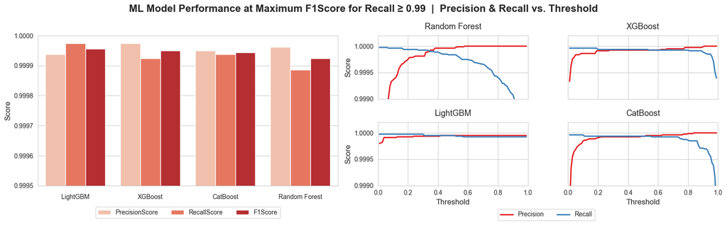

The ROC curves for the top four models are nearly identical and exhibit a near-square shape, indicating extremely high class separability and similar ranking performance. This suggests that model choice has minimal impact, as the underlying feature space already allows for near-perfect discrimination between classes. Differences in classification metrics are therefore negligible and within expected variance.

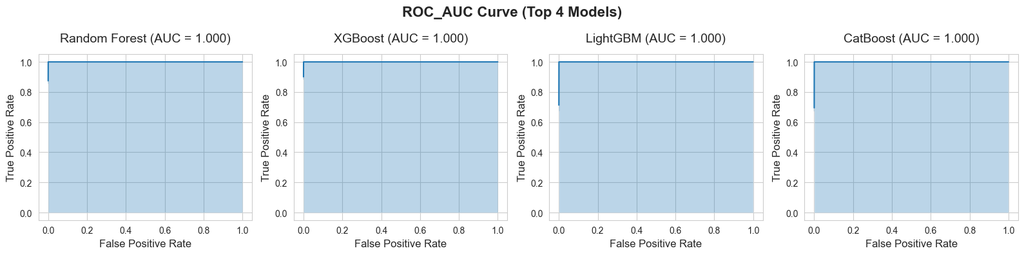

The calibration curves for the top-performing models exhibit irregular shapes, particularly in the mid-probability range. This behavior is primarily due to the highly confident predictions produced by the models, with most probabilities concentrated near 0 or 1. As a result, intermediate probability bins contain relatively few samples, leading to instability in the estimated true probabilities. This reflects the strong separability of the dataset rather than poor model performance. While tree-based models tend to produce overconfident probability estimates, the limited presence of ambiguous cases reduces the practical importance of calibration in this context.

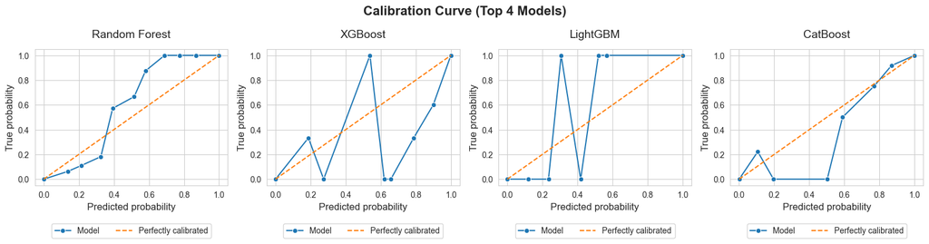

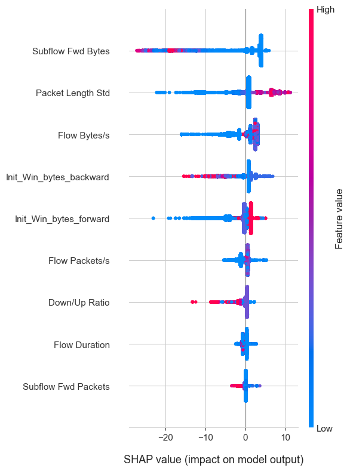

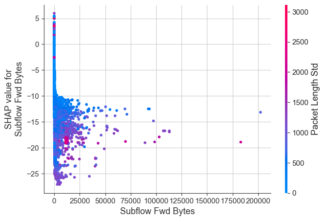

## Conclusion

Feature selection analysis, combined with correlation analysis, indicates that a reduced subset of variables captures most of the predictive signal, while several features are redundant, contribute negligibly, or introduce noise that can degrade model performance. The dataset contains features that provide a strong and clear signal for distinguishing attack traffic from normal traffic, resulting in near-perfect class separation across multiple models. This suggests that the high performance observed is driven not only by model capability, but also by the strong intrinsic separability of the dataset in the selected feature space.